# Question

Un arquitecto tiene un tubo de forma cilíndrica. El tubo tiene una base circular de radio 3 cm y una altura de 7 cm, como se muestra en la figura.

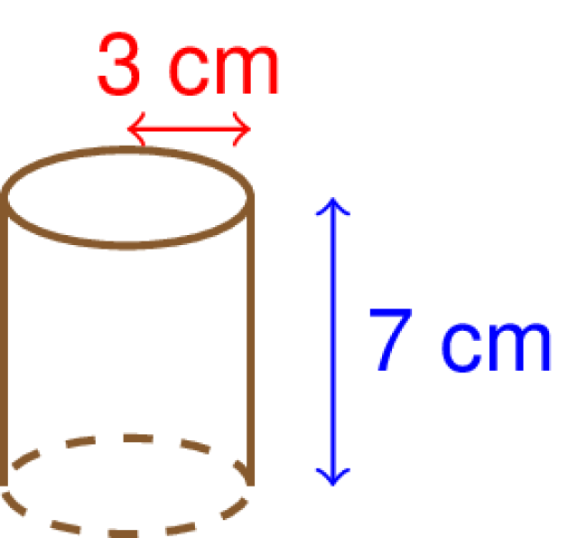

A partir de la información anterior, el arquitecto plantea la siguiente operación:

$$\pi \times 3^2 \times 7 =
197.92$$

**¿A qué corresponde el resultado de la anterior operación?**

## Answerlist

- Al volumen del tubo.
- Al área de la tapa del tubo.
- Al perímetro de la tapa del tubo.
- Al área lateral del tubo.

# Solution

Para resolver este problema, debemos identificar qué magnitud geométrica corresponde a la expresión matemática planteada.

### Análisis de la operación

La operación planteada es:

$$\pi \times 3^2 \times 7 =
197.92$$

Donde:

- $r = 3$ cm (radio de la base circular)
- $h = 7$ cm (altura del cilindro)

### Fórmulas relevantes del cilindro

Para un cilindro de radio $r$ y altura $h$, tenemos las siguientes fórmulas:

1. **Volumen del cilindro:** $V = \pi r^2 h$
2. **Área de la tapa (círculo):** $A_{tapa} = \pi r^2$
3. **Perímetro de la tapa (circunferencia):** $P_{tapa} = 2\pi r$
4. **Área lateral del cilindro:** $A_{lateral} = 2\pi r h$

### Comparación con la operación dada

La expresión $\pi \times 3^2 \times 7$ tiene la estructura:

$$\pi \times r^2 \times h$$

Comparando con las fórmulas anteriores, observamos que **esta expresión corresponde exactamente a la fórmula del volumen del cilindro**:

$$V = \pi r^2 h = \pi \times 3^2 \times 7
= 197.92 \text{ cm}^3$$

### Verificación de otras opciones

Verifiquemos por qué las otras opciones son incorrectas:

**Área de la tapa:**
$$A_{tapa} = \pi r^2 = \pi \times 3 ^2
= 28.27 \text{ cm}^2$$
Esta fórmula NO incluye la altura.

**Perímetro de la tapa:**
$$P_{tapa} = 2\pi r = 2 \times \pi
\times 3 = 18.85 \text{ cm}$$
Esta fórmula NO incluye $r^2$ ni la altura.

**Área lateral:**
$$A_{lateral} = 2\pi r h = 2 \times \pi
\times 3 \times 7 = 131.95 \text{ cm}^2$$
Esta fórmula NO incluye $r^2$ (solo $r$).

### Conclusión

La operación $\pi \times 3^2 \times 7 = 197.92$ corresponde al **volumen del tubo**, medido en centímetros cúbicos (cm³).

La estructura $\pi r^2 h$ es característica de la fórmula del volumen de un cilindro, donde:

- $\pi r^2$ representa el área de la base circular
- Al multiplicar por la altura $h$, obtenemos el volumen total

## Answerlist

- Verdadero. La fórmula $\pi r^2 h$ corresponde al volumen del cilindro.
- Falso. El área de la tapa sería $\pi r^2$ (sin la altura).
- Falso. El perímetro de la tapa sería $2\pi r$ (no incluye $r^2$ ni altura).
- Falso. El área lateral sería $2\pi r h$ (con $r$ en lugar de $r^2$).

# Meta-information

exname: volumen_cilindro_interpretacion_formula extype: schoice exsolution: 1000 exshuffle: TRUE exsection: Geometría|Cilindro|Volumen|Interpretación exextra[Type]: Interpretación y representación exextra[Level]: 2 exextra[Language]: es exextra[Course]: Matemáticas ICFES exextra[Componente]: Geométrico-Métrico exextra[Pensamiento]: Métrico y Espacial